# hw8

Charles Yang

11/7/2021

```r
setwd("C:/Users/15155/Desktop/ds303/hw8/mnist")
train <- NULL
test <- NULL
load_mnist()
```

```r
numberTrainIndex = sample(1:train$n, 3000)
numberTestIndex = sample(1:test$n, 100)

numberTrainX = train$x[numberTrainIndex, ]
numberTrainY = train$y[numberTrainIndex]
numberTestX = test$x[numberTestIndex, ]
numberTestY = test$y[numberTestIndex]
```

```r
K = c(1, 5, 7, 9)
flds <- createFolds(numberTrainY, k = 10, list = TRUE, returnTrain = FALSE)

cvMisclassification = matrix(NA, 10, 4)

for(j in 1:4){
  k = K[j]
  for(i in 1:10){
    test_index = flds[[i]]

    testX = numberTrainX[test_index, ]
    trainX = numberTrainX[-test_index, ]

    testY = numberTrainY[test_index]
    trainY = numberTrainY[-test_index]

    knn.pred = knn(trainX, testX, trainY, k=k)
    cvMisclassification[i,j] = mean(testY != knn.pred)
  }
}
```

```r
bestK = which.min(apply(cvMisclassification,2,mean))

train.X = numberTrainX
train.Y = numberTrainY
test.X = numberTestX
knn.pred = knn(train.X, test.X, train.Y, k=K[bestK])

print(paste0("Best K: ", K[bestK]))
```

```
## [1] "Best K: 1"
```

```r
table(knn.pred, numberTestY)
```

```
##         numberTestY
## knn.pred  0  1  2  3  4  5  6  7  8  9
##        0  6  0  1  0  0  0  0  0  0  0
##        1  0  8  0  0  1  1  0  0  0  2
##        2  0  0  7  1  0  0  0  0  0  0
##        3  0  0  0  7  0  0  0  0  0  0
##        4  0  0  0  0  6  0  0  1  0  1
##        5  0  0  0  0  0 11  0  0  0  0
##        6  0  0  0  0  0  0  8  0  0  0
##        7  0  0  0  0  0  0  0  9  0  1
##        8  0  0  1  1  0  1  0  0 14  0
##        9  0  0  0  0  0  0  0  0  0 12
```

```r
mean(numberTestY == knn.pred)
```

```
## [1] 0.88
```

```r
mean(numberTestY != knn.pred)
```

```
## [1] 0.12
```

```r
numberTrainDF <- data.frame(cbind(numberTrainX, numberTrainY))

lda.fit = lda(numberTrainY~., data=numberTrainDF)
```

[output not shown]

```r
multinom(numberTrainY~., data=numberTrainDF)
```

```
## Error in nnet.default(X, Y, w, mask = mask, size = 0, skip = TRUE, softmax = TRUE, : too many (7860) weights
```

1. Number Classifier

b. We get that some variables are constant. This means that the covariance matrix was singular, making it impossible to compute the inverse.

c. We get an error saying that there's too many weights.

d. This dataset has a few problems: The covariance matrices are completely useless to other methods of classification. This is not a problem for KNN. Additionally, we have a large amount of data, for which KNN performs will with.

```r
setwd("C:/Users/15155/Desktop/ds303/hw8/fashion-mnist")
train <- NULL
test <- NULL
load_mnist()
```

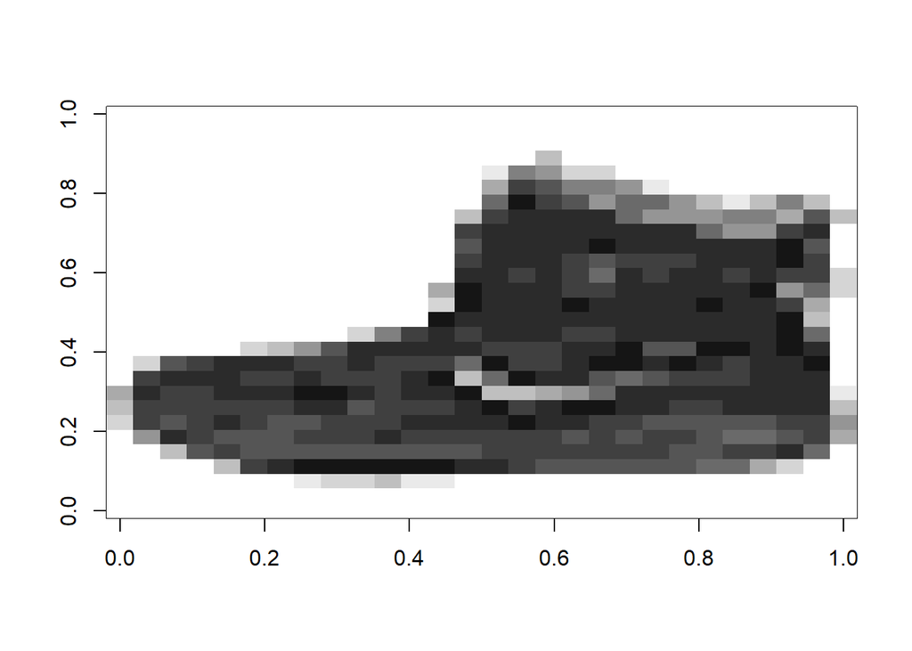

```r
show_digit(train$x[1, ])
```

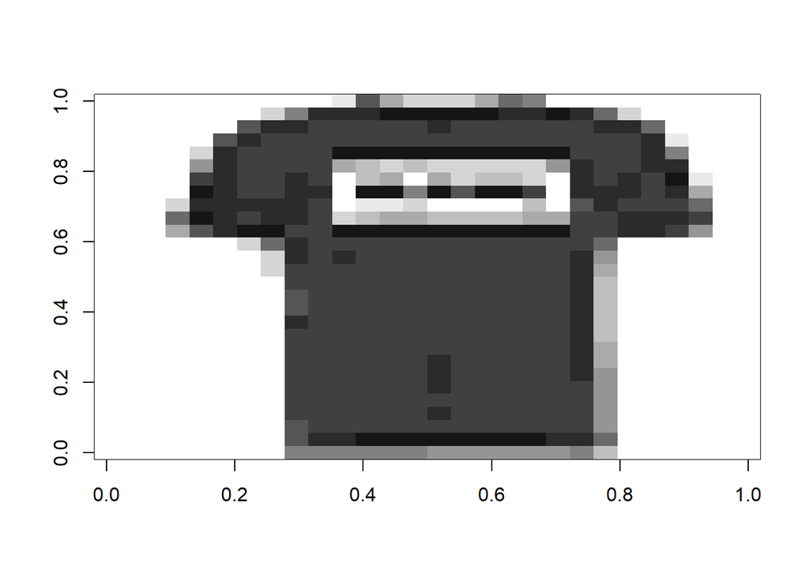

```r
show_digit(train$x[2, ])
```

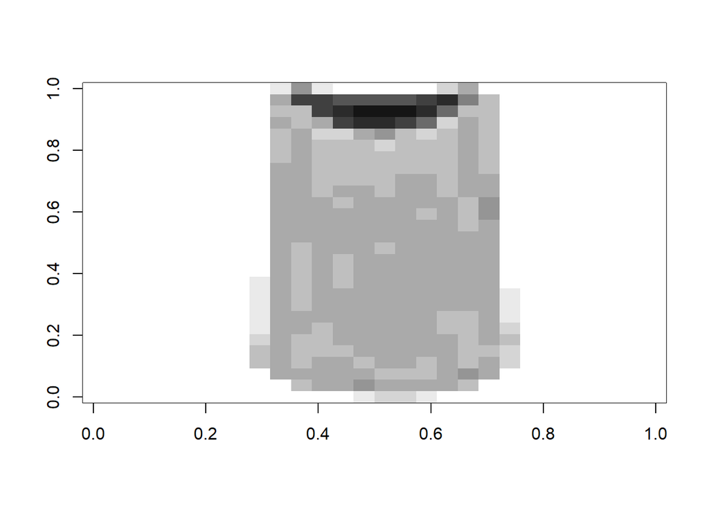

```r
show_digit(train$x[3, ])
```

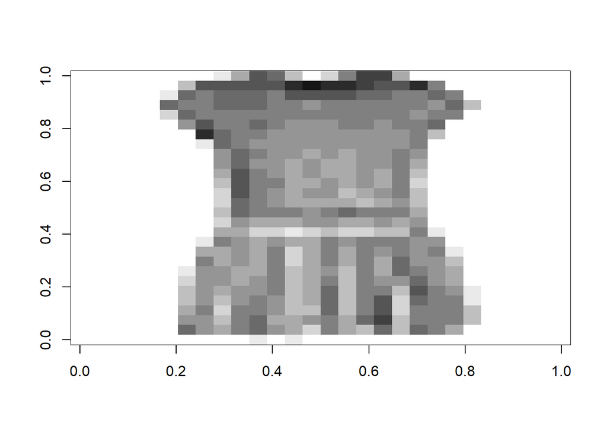

```r
show_digit(train$x[4, ])
```

[figure not shown]

```r
show_digit(train$x[5, ])
```

```r
numberTrainIndex = sample(1:train$n, 3000)
numberTestIndex = sample(1:test$n, 100)

numberTrainX = train$x[numberTrainIndex, ]
numberTrainY = train$y[numberTrainIndex]
numberTestX = test$x[numberTestIndex, ]
numberTestY = test$y[numberTestIndex]
```

```r
K = c(1, 5, 7, 9)
flds <- createFolds(numberTrainY, k = 10, list = TRUE, returnTrain = FALSE)

cvMisclassification = matrix(NA, 10, 4)

for(j in 1:4){
  k = K[j]
  for(i in 1:10){
    test_index = flds[[i]]

    testX = numberTrainX[test_index, ]
    trainX = numberTrainX[-test_index, ]

    testY = numberTrainY[test_index]
    trainY = numberTrainY[-test_index]

    knn.pred = knn(trainX, testX, trainY, k=k)
    cvMisclassification[i,j] = mean(testY != knn.pred)
  }
}
```

```r
bestK = which.min(apply(cvMisclassification,2,mean))

train.X = numberTrainX
train.Y = numberTrainY
test.X = numberTestX
knn.pred = knn(train.X, test.X, train.Y, k=K[bestK])

print(paste0("Best K: ", K[bestK]))
```

```
## [1] "Best K: 7"
```

```r
table(knn.pred, numberTestY)
```

```
##         numberTestY
## knn.pred  0  1  2  3  4  5  6  7  8  9
##        0  7  0  1  1  0  0  3  0  0  0
##        1  0 10  0  0  0  0  0  0  0  0
##        2  0  0  6  0  0  0  1  0  1  0
##        3  2  0  0  5  0  0  1  0  0  0
##        4  1  1  0  1  7  0  1  0  0  0
##        5  0  0  0  0  0  6  0  0  0  0
##        6  1  0  1  0  0  0  4  0  1  0
##        7  0  0  0  0  0  2  0 16  0  0
##        8  0  0  0  0  0  0  0  0 10  0
##        9  0  0  0  0  0  2  0  3  0  5
```

```r
mean(numberTestY == knn.pred)
```

```
## [1] 0.76
```

```r
mean(numberTestY != knn.pred)
```

```
## [1] 0.24
```

2. Fashion Classifier

a. Man, I can barely make out the first 2 items. They are a shoe and a t-shirt. IDK about the rest. The fourth might be a dress? Super blurry.